# AB-test-analysis

Daniel Verdejo id=22240224

2022-11-04

A company is interested in investigating whether adding a new variant to a particular website will improve i) the visit through time and ii) the proportion of query items resolved compared to that observed in the current website. A sample of 300 customers were directed to either the current or new variant of the website and their visit through time whether or not their query was resolved was recorded.

```r
library("tidyverse")
library("tolerance")
data <- data.frame(read.csv("./ab_test.csv", header = TRUE, sep = ","))

set.seed(626) # set the seed for a repeatable results

threshold <- floor(55 * 0.7)

calculateProbability <- function(events, allPossibleOutcomes) {
  return (round(events / allPossibleOutcomes, 3))
}

eventsAboveThresholdExperiment <- function(sample, noOfDays) {
  days <- list()

  for (x in 1:noOfDays) { # for no of days, gather samples of size 55 where resolution status is "Yes"
    day <- slice_sample(sample, n = 55)
    day <- day %>% select(Resolved) %>% filter(Resolved == "Yes")
    day <- count(day)$n
    days <- append(days, day)
  }

  # count and return the number of events which meet our condition
  daysMetCondition <- which(days >= threshold)
  noOfEvents <- length(daysMetCondition)
  return (noOfEvents)
}

calcIntervalEstimateTime <- function(variant, variantCnt) {
  sigma <- sqrt(sum((variant$Time - 180)**2) / variantCnt)

  stdErrMean <- sigma / (sqrt(variantCnt))

  marginOfErr <- qnorm(.95) * stdErrMean

  intervalEst <- mean(variant$Time)
  intervalEst <- intervalEst + c(-marginOfErr, marginOfErr)
  return (intervalEst)
}

calcIntervalEstimateResolution <- function(variant, variantCnt) {
  sigma <- (sqrt(sum(variant$ResolvedNumeric)**2) / variantCnt)

  stdErrMean <- sigma / (sqrt(variantCnt))

  marginOfErr <- qnorm(.95) * stdErrMean

  intervalEst <- mean(variantCnt)
  intervalEst <- intervalEst + c(-marginOfErr, marginOfErr)
  return (intervalEst)
}
```

```r
variantB <- data %>%
  select(Variant, Time, Resolved) %>%
  filter(Variant == 'B')

visitsBelow3minVarB <- variantB %>%
  select(Time) %>%
  filter(Time < 180)

variantBCnt <- count(variantB)$n
visitsBelow3minVarBCnt <- count(visitsBelow3minVarB)$n

varBProbabilityVisitBelow3min <- calculateProbability(visitsBelow3minVarBCnt ,variantBCnt)

sprintf("Probability of a visit time below 3 minutes on the new variant (Variant B) = %s / %s = %s", visitsBelow3minVarBCnt, variantBCnt, varBProbabilityVisitBelow3min)
```

```
## [1] "Probability of a visit time below 3 minutes on the new variant (Variant B) = 49 / 150 = 0.327"
```

To calculate this probability we first gathered a sample where the Variant is “B”, this contained 150 data points. Next we gathered a sample of the Variant B sample where the Time value was less than 3 minutes, this contained 49 data points. Using these counts, we calculate the probability by doing the following:

*probability of a visit through time less than 3 minutes = number of Variant B data points where Time is less than 3 minutes / number of Variant B data points*

> Our probability that a random customer will have a visit through time below 3 minutes was a score of: **0.327**

calc probability that at least 70% of queries on the new site will be resolved in a day where it is assumed that 55 customers visit the site in a day.

Next we will take a sample of 55 customers from the Variant B sample

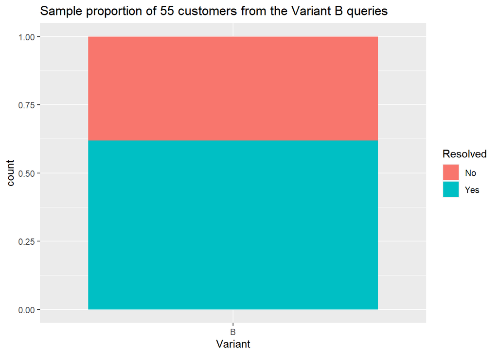

```r
oneDaySample <- sample_n(variantB, 55) %>%
  summarise(count= n(), Time, Resolved, Variant)

ggplot(data = oneDaySample, aes(x = Variant, y = count, fill = Resolved)) +
  geom_bar(position = "fill", stat = "identity") +
  ggtitle("Sample proportion of 55 customers from the Variant B queries")
```

```r
noOfDays <- 91 # for a calendar quater of days
eventsAboveThresholdVarB <- eventsAboveThresholdExperiment(variantB, noOfDays)

probabilityResolvedAboveThresholdVarB <- calculateProbability(eventsAboveThresholdVarB, noOfDays)

sprintf("probability that at least 70 percent of queries on the new site will be resolved in a day where it is assumed that 55 customers visit the site = %s", probabilityResolvedAboveThresholdVarB)
```

```
## [1] "probability that at least 70 percent of queries on the new site will be resolved in a day where it is assumed that 55 customers visit the site = 0.121"
```

> Our probability that at least 70% of queries on the new site will be resolved in a day where it is assumed that 55 customers visit the site was a score of: **0.121**

Lets compare Variant A on the same probabilities we gathered for Variant B

```r
variantA <- data %>%
  select(Variant, Time, Resolved) %>%
  filter(Variant == 'A')

visitsBelow3minVarA <- variantA %>%
  select(Time) %>%
  filter(Time < 180)

variantACnt <- count(variantA)$n
visitsBelow3minVarACnt <- count(visitsBelow3minVarA)$n

varAProbabilityVisitBelow3min <- calculateProbability(visitsBelow3minVarACnt, variantACnt)

sprintf("Probability of a visit time below 3 minutes on the old variant (Variant A) = %s / %s = %s", visitsBelow3minVarACnt, variantACnt, varAProbabilityVisitBelow3min)
```

```
## [1] "Probability of a visit time below 3 minutes on the old variant (Variant A) = 0 / 150 = 0"
```

```r
eventsAboveThresholdVarA <- eventsAboveThresholdExperiment(variantA, noOfDays)

probabilityResolvedAboveThresholdVarA <- calculateProbability(eventsAboveThresholdVarA, noOfDays)

sprintf("probability that at least 70 percent of queries on the old site will be resolved in a day where it is assumed that 55 customers visit the site = %s", probabilityResolvedAboveThresholdVarA)
```

```
## [1] "probability that at least 70 percent of queries on the old site will be resolved in a day where it is assumed that 55 customers visit the site = 0"
```

### The design used

> To gather the probability for both of our experiments the following equation is used:

> *P = # of events which meet our condition / total # of outcomes in our sample*

To gather the probability in our experiment: *a visit will be below 3 minutes on the new site* we use a simple enough calculation:

1. We count the number of events which meet our condition: The *Time* value is less than (<) 180 seconds.
2. We count the total number of outcomes: Count all *Time* values found in our sample.
3. We calculate probability by using these like so: P = *visitsBelow180Sec / allVisits*

The same mechanism was used to gather the probability of a visit through time below 3 minutes on the old site - “Variant A”.

To gather the probability that *70 percent of queries will be resolved on a day where 55 customers visit the site* we use random sampling of rows for the given variant.

### Concerns with the design used.

The experiment used to gather the probability for the 2nd experiment **70 percent of queries will be resolved on a day where 55 customers visit the site** is not likely to be a true representation of what an average quarter of a year would actually look like in terms of visits per day. It is very likely to have more or less than 55 visits per day but does give a somewhat faithful representation of the probability if you had an average of 55 visits per day. Also the threshold of 70% of 55 worked out to be 38.5 which was rounded down to 38, the data would have differed had we rounded up to 39 (less days would have met the criteria).

### Numerical and graphical summaries

Now that we have recorded the same probabilities on both variants we can compare the 2 against each other:

```r
variants <- unique(sort(data$Variant))
probabilityvisitDurationLessThan3Minutes <- c(varAProbabilityVisitBelow3min, varBProbabilityVisitBelow3min)
probabilityResolvedAbove70percent <- c(probabilityResolvedAboveThresholdVarA, probabilityResolvedAboveThresholdVarB)

comparedProbabilities <- data.frame(variants, probabilityvisitDurationLessThan3Minutes, probabilityResolvedAbove70percent)
comparedProbabilities %>%
  select(variants, probabilityvisitDurationLessThan3Minutes, probabilityResolvedAbove70percent) %>%
  summarise(Variant = variants,
            "Probability of visit less than 3 minutes" = probabilityvisitDurationLessThan3Minutes,
            "Probability of resolved queries above 70% on a random day with 55 visits" = probabilityResolvedAbove70percent)
```

```
##   Variant Probability of visit less than 3 minutes
## 1       A                                    0.000
## 2       B                                    0.327
##   Probability of resolved queries above 70% on a random day with 55 visits
## 1                                                                    0.000
## 2                                                                    0.121
```

Lets visualise the proportion of resolved to unresolved queries the difference of resolved queries between variants

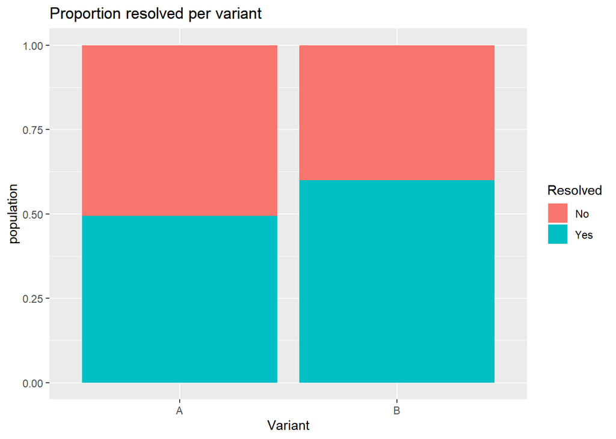

```r
population = count(data)$n

ggplot(data, aes(fill=Resolved, y=population, x=Variant)) +
  geom_bar(position = "fill", stat = "identity") +
  ggtitle("Proportion resolved per variant")
```

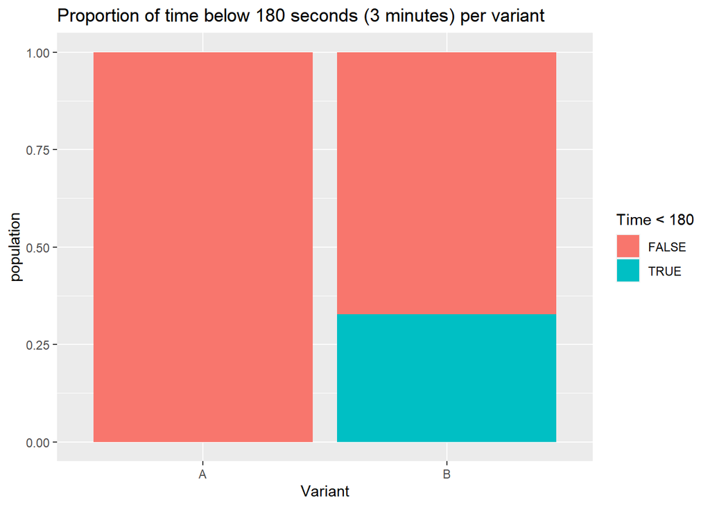

```r
ggplot(data, aes(fill=Time<180, y=population, x=Variant)) +
  geom_bar(position = "fill", stat = "identity") +
  ggtitle("Proportion of time below 180 seconds (3 minutes) per variant")
```

As we can see from stacked bar chart there is a higher proportion of resolved queries on variant B vs variant A. Additionally there is a higher proportion of visits below 180 seconds on variant B vs variant A.

**Comparrison of Time on both variants**

Below we can see from the distribution of times for variant A across the histogram. Our times for each visit fall between ~200 and ~400. This confirms our finding that the probability of a visit being below 180 seconds (3 minutes) is 0.0. We can further confirm this by looking at our minimum, mean and maximum time found in the variant a sample.

The distribution of times differs for variant B. Our time distribution range is significantly lower on the min and max. Additionally we see that there is indeed records below the 180 second thus confirming our finding that the probability of a visit being below 180 seconds (3 minutes) is 0.327. We can further confirm this by looking at our minimum, average and maximum times and comparing them with the same found in the variant A sample.

```r
sprintf("Variant A minimum time: %s, average time: %s, maximum time: %s", min(variantA$Time),  mean(variantA$Time),max(variantA$Time))
```

```
## [1] "Variant A minimum time: 198.3982328, average time: 290.147304824667, maximum time: 399.8961417"
```

```r
sprintf("Variant B minimum time: %s, average time: %s, maximum time: %s", min(variantB$Time),  mean(variantB$Time),max(variantB$Time))
```

```
## [1] "Variant B minimum time: 92.88388724, average time: 207.1608439414, maximum time: 319.5104722"
```

As we can see the minimum is as low as ~93 seconds, over 100 seconds faster than our previous minimum and our max time is closer to our previous mean at ~319 seconds (+10%) but ~80 seconds lower than our previous max. The mean time on the new variant is quite close to our 180 second target at 207 seconds further reinforcing the probability found for this metric.

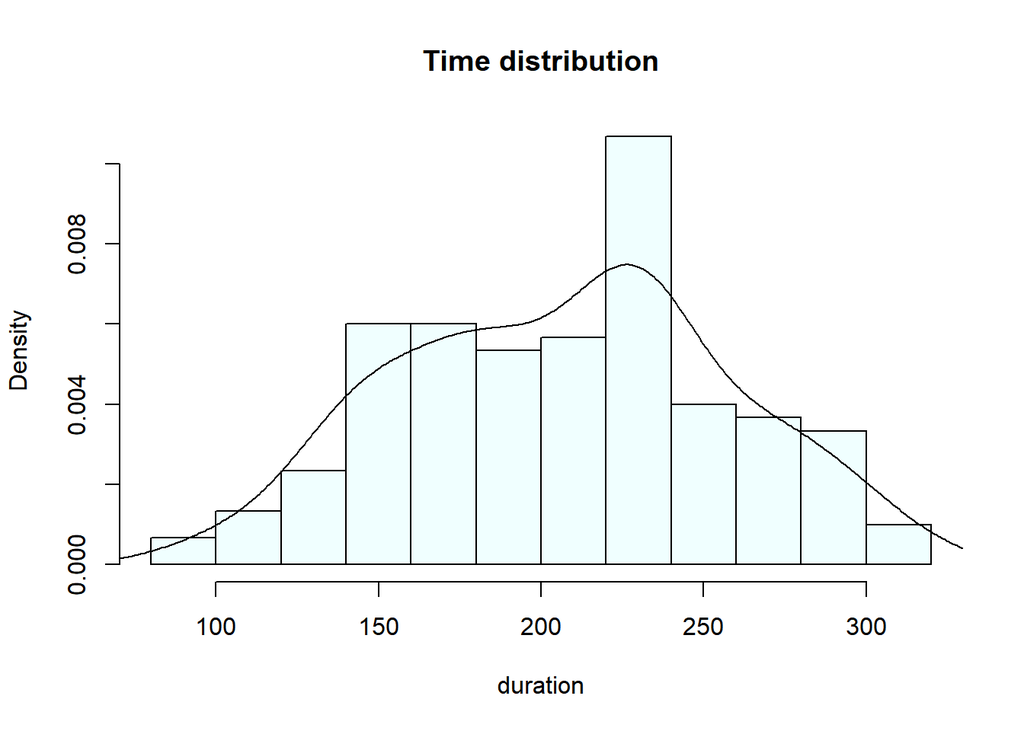

```r
hist(variantB$Time, main = "Time distribution", xlab = "duration", prob = TRUE, col = "azure")

lines(density(variantB$Time))
```

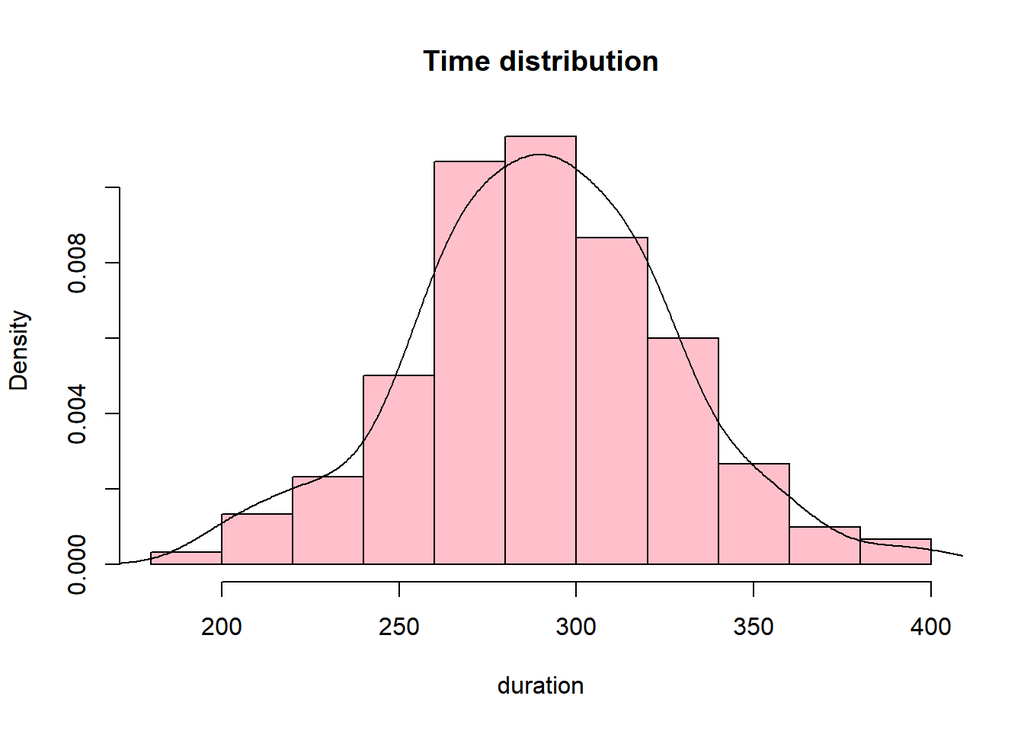

```r
hist(variantA$Time, main = "Time distribution", xlab = "duration", prob = TRUE, col="pink")

lines(density(variantA$Time))
```

### Hypothesis test

Lets test a sample from variant B and gather our confidence interval, sample mean, degrees of freedom and alternative hypothesis

```r
t.test(variantB$Time, mu = 180)
```

```
##
##  One Sample t-test
##
## data:  variantB$Time
## t = 6.5938, df = 149, p-value = 6.985e-10
## alternative hypothesis: true mean is not equal to 180
## 95 percent confidence interval:
##  199.0214 215.3003
## sample estimates:
## mean of x
##  207.1608
```

```r
variantB <- variantB %>%
  mutate(ResolvedNumeric = ifelse(Resolved == "Yes", 1, 0))
t.test(variantB$ResolvedNumeric, mu = .7)
```

```
##
##  One Sample t-test
##
## data:  variantB$ResolvedNumeric
## t = -2.4917, df = 149, p-value = 0.01381
## alternative hypothesis: true mean is not equal to 0.7
## 95 percent confidence interval:
##  0.5206947 0.6793053
## sample estimates:
## mean of x
##       0.6
```

As we can see from our result for **Time** the sample mean is higher at 207.161 than the null hypothesis value of 180. There is convincing evidence as the p-value is very small that the mean is not consistent with the null hypothesis value thus we can reject the null hypothesis.

Likewise for our result for **Resolved** the sample mean is lower than our target of .7. our p-value is also quite small, therefore we can reject the null hypothesis value.

Lets repeat for Variant A

```r
t.test(variantA$Time, mu= 180)
```

```
##
##  One Sample t-test
##
## data:  variantA$Time
## t = 36.722, df = 149, p-value < 2.2e-16
## alternative hypothesis: true mean is not equal to 180
## 95 percent confidence interval:
##  284.2202 296.0744
## sample estimates:
## mean of x
##  290.1473
```

```r
variantA <- variantA %>%
  mutate(ResolvedNumeric = ifelse(Resolved == "Yes", 1, 0))
t.test(variantA$ResolvedNumeric, mu = .7)
```

```
##
##  One Sample t-test
##
## data:  variantA$ResolvedNumeric
## t = -5.0458, df = 149, p-value = 1.297e-06
## alternative hypothesis: true mean is not equal to 0.7
## 95 percent confidence interval:
##  0.4123999 0.5742668
## sample estimates:
## mean of x
## 0.4933333
```

**Time** - We see here our mean is much further away from our target of 180 seconds, we can reject the null hypothesis given our p-value is even smaller than the previous test.

**Resolved** - Again our mean of x is lower than the hypothesis value of .7 and our p-value is minute therefore we can safely reject the null hypthesis value.

### Interval estimation

Variant B Time & Resolution interval estimate

```r
calcIntervalEstimateTime(variantB, variantBCnt)
```

```
## [1] 199.4859 214.8358
```

```r
calcIntervalEstimateResolution(variantB, variantBCnt)
```

```
## [1] 149.9194 150.0806
```

Variant A Time & Resolution interval estimate

```r
calcIntervalEstimateTime(variantA, variantACnt)
```

```
## [1] 274.5585 305.7361
```

```r
calcIntervalEstimateResolution(variantA, variantACnt)
```

```
## [1] 149.9337 150.0663
```

### 95/95 Tolerance interval

```r
out <- normtol.int(variantB$Time, alpha = 0.05, P = 0.95, side = 1, method = "EXACT")
out
```

```
##   alpha    P    x.bar 1-sided.lower 1-sided.upper
## 1  0.05 0.95 207.1608      112.8299      301.4918
```

```r
out <- normtol.int(variantA$Time, alpha = 0.05, P = 0.95, side = 1, method = "EXACT")
out
```

```
##   alpha    P    x.bar 1-sided.lower 1-sided.upper
## 1  0.05 0.95 290.1473      221.4561      358.8385
```

### Conclusion

We see that from the data gathered and the 2 probabilities we have calculated the new site has:

1. A higher probability that a visit through time will be less than 3 minutes.
2. A higher probability that 70% of queries on the site will be resolved in a day where we assume 55 customers visit the site.

From these 2 data points alone we could say that new site (Variant B) shows an improvement over the previous variant, but we also found other benefits to the new site including:

1. Lower minimum, average, and maximum visit times
2. A higher proportion of resolved queries (“Yes” responses)

In conclusion given that we see improvements across multiple data points I would feel confident in recommending changing to Variant B.